# Data Tidying Assignment

Data Tidying and Reporting

Mario Fernández Ruiz & David Crespo Acero

21/03/2022

In this assignment we will carry out an analysis of the novel *Dracula*, by Bram Stoker (1897). To do this, we will use the tools provided by $\texttt{quanteda}$ library.

# 1 Preprocessing

We can load the text from *Dracula* using the **readtext** package, directly from the [Project Gutenberg website](https://www.gutenberg.org/files/345/345-0).

```r
data_char_dracula <- texts(readtext("https://www.gutenberg.org/files/345/345-0.txt"))
names(data_char_dracula) <- "Dracula"
```

Next step is to separate actual content from metadata, since the Gutenberg edition of the text contains some metadata before and after the text of the novel.

We can not use the “CHAPTER I” as the beginning of the novel as these words appear previously in the table of contents. Hence, we need to include the next line too, which is “JONATHAN HARKER’S JOURNAL”. The last word in the novel is easier to find, it is “sake”.

```r
# extract the header information
(start_v <- stri_locate_first_fixed(data_char_dracula,
    "CHAPTER I

JONATHAN HARKER'S JOURNAL")[1])
```

```
[1] 2675
```

```r
(end_v <- stri_locate_last_fixed(data_char_dracula,
    "sake.")[1])
```

```
[1] 844820
```

Now, we trim the non-book content, extracting the text between the beginning and ending indexes found above:

```r
novel_v <- stri_sub(data_char_dracula, start_v, end_v)
```

Finally, to make the analysis easier we convert all the text to lower case.

```r
# lowercase text
novel_lower_v <- char_tolower(novel_v)
```

# 2 Analysis of occurrence of words related with love or positive feelings.

We can use the function `kwic` to count how many occurrences of these words (and its derivations) are found in the text. The words that were chosen are **love, joy, happy, kiss, pleasure, and passion**.

```r
love <- nrow(kwic(novel_lower_v, pattern = "love*"))
joy <- nrow(kwic(novel_lower_v, pattern = "joy*"))
happy <- nrow(kwic(novel_lower_v, pattern = "happy*"))
kiss <- nrow(kwic(novel_lower_v, pattern = "kiss*"))
pleasure <- nrow(kwic(novel_lower_v, pattern = "pleasure*"))
passion <- nrow(kwic(novel_lower_v, pattern = "passion*"))
```

Then, we can make frequency plots from the previous results.

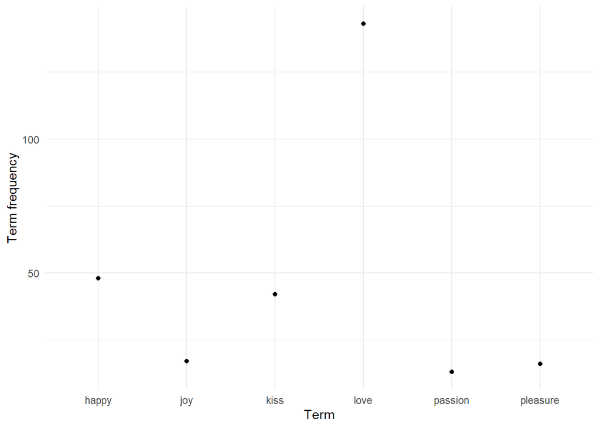

```r
to_plot <- c(love, joy, happy, kiss, pleasure, passion)
rank <- c(1, 2, 3, 4, 5)
word <- c("love", "joy", "happy", "kiss", "pleasure",
    "passion")

mi_df <- data.frame(frequency = to_plot, word = word)

library(ggplot2)
theme_set(theme_minimal())
ggplot(mi_df, aes(x = word, y = frequency)) + geom_point() +
    labs(x = "Term", y = "Term frequency")
```

As it can be seen, **love** and **happy** are the two “positive feelings”-words that appear the most. It was expected that these words were the most common, as they literally represent the joy-sentiments we were looking for.

# 3 Analysis of frequency of some common words.

First, we will see if these words (personal pronouns mainly) are among the most used in the novel. We use $\texttt{dfm()}$ command to create a matrix of counts of each word type – a document-frequency matrix.

```r
dracula_dfm <- dfm(novel_lower_v, remove_punct = TRUE)
word_freq <- textstat_frequency(dracula_dfm, n = 40)
word_freq
```

```
   feature frequency rank docfreq group
1      the      7875    1       1   all
2      and      5898    2       1   all
3        i      4797    3       1   all
4       to      4465    4       1   all
5       of      3611    5       1   all
6        a      2918    6       1   all
7       he      2567    7       1   all
8       in      2497    8       1   all
9     that      2465    9       1   all
10      it      2148   10       1   all
11     was      1878   11       1   all
12      as      1590   12       1   all
13      we      1543   13       1   all
14     for      1534   14       1   all
```

[output cut: 26 more lines]

As we can see, all of them are among the 40 most used words. Then, from this list we will select the personal pronouns.

```r
pronoun_freq <- word_freq[c(3, 7, 10, 13, 16, 17, 19,
    28, 31, 32)]
```

Now, we can plot the term frequency for each of these pronouns

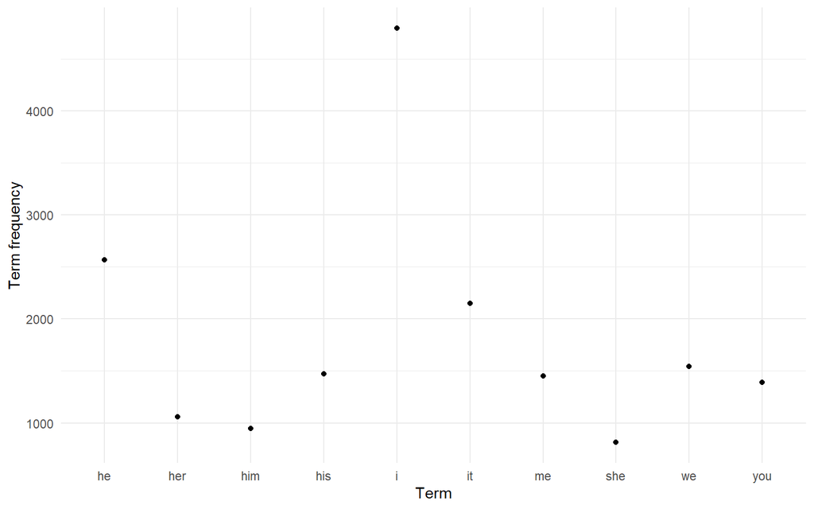

```r
theme_set(theme_minimal())
pronoun_freq %>%
    ggplot(aes(x = feature, y = frequency)) + geom_point() +
    labs(x = "Term", y = "Term frequency")
```

It is not a surprise that the pronoun I is the most used one as this novel is narrated through a series of first person documents (diary, journal).

Now, we will show the relative frequencies too, so we need to know the total number of tokens. Also, we also create the sorted list of the frequency of the words we are using.

```r
number_token <- ntoken(dracula_dfm)
number_token
```

```
 text1
161172
```

```r
sorted_dracula_freqs_t <- topfeatures(dracula_dfm,
    n = nfeat(dracula_dfm))
sorted_dracula_freqs_t <- sorted_dracula_freqs_t[c("i",
    "he", "it", "we", "his", "me", "you", "her", "him",
    "she")]
```

Thus, relative frequencies for the terms are:

```r
sorted_dracula_rel_freqs_t <- sorted_dracula_freqs_t/number_token *
    100
sorted_dracula_rel_freqs_t["i"]
```

```
       i
2.976323
```

We plot the relative frequency of the terms.

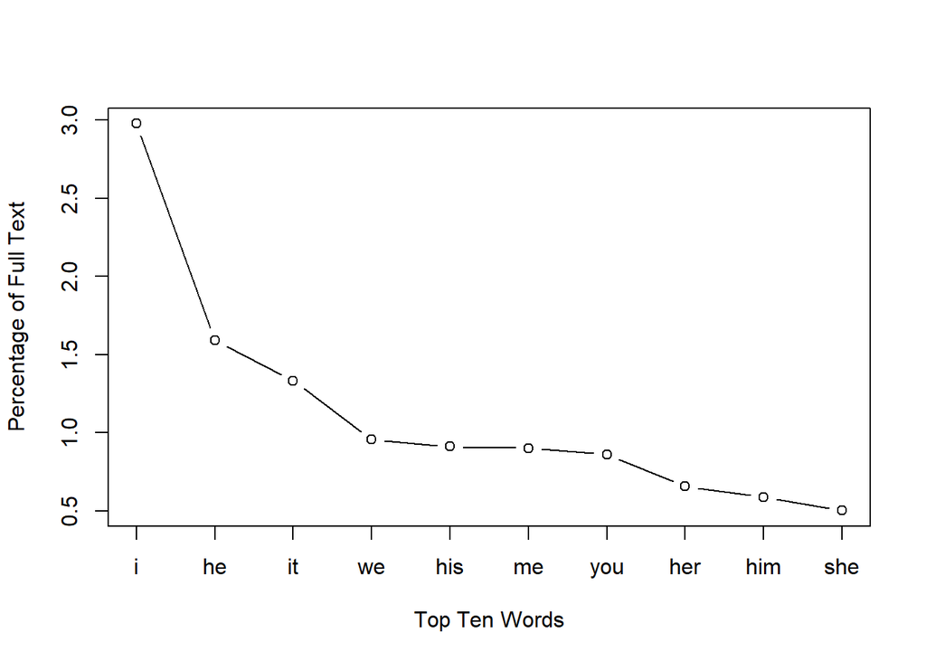

```r
plot(sorted_dracula_rel_freqs_t[1:10], type = "b",
    xlab = "Top Ten Words", ylab = "Percentage of Full Text",
    xaxt = "n")
axis(1, 1:10, labels = names(sorted_dracula_rel_freqs_t[1:10]))
```

Also, we can use ggplot to get a bar graph, but we need the data in data frame format.

```r
# by weighting the dfm directly
dracula_dfm_pct <- dfm_weight(dracula_dfm, scheme = "prop") *
    100

dracula_dfm_pct <- dfm_select(dracula_dfm_pct, pattern = c("i",
    "he", "it", "we", "his", "me", "you", "her", "him",
    "she"))
```

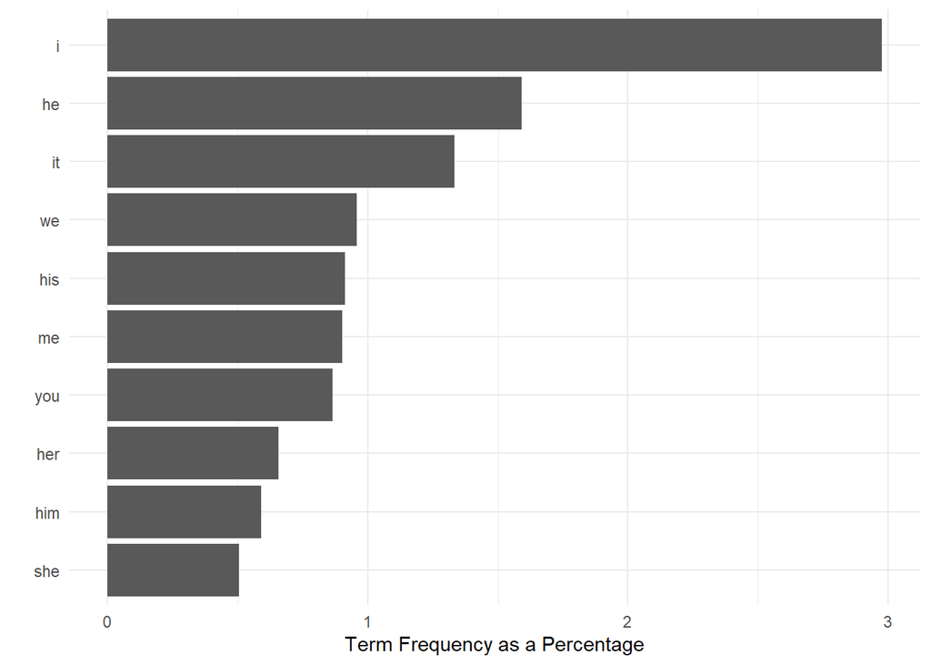

```r
textstat_frequency(dracula_dfm_pct, n = 10) %>%
    ggplot(aes(x = reorder(feature, -rank), y = frequency)) +
    geom_bar(stat = "identity") + coord_flip() + labs(x = "",
    y = "Term Frequency as a Percentage")
```

# 4 Token distribution analysis

We can use dispersion plots to see the occurrences of different terms throughout the text. We can try with some of the positive feelings related words previously used, for example.

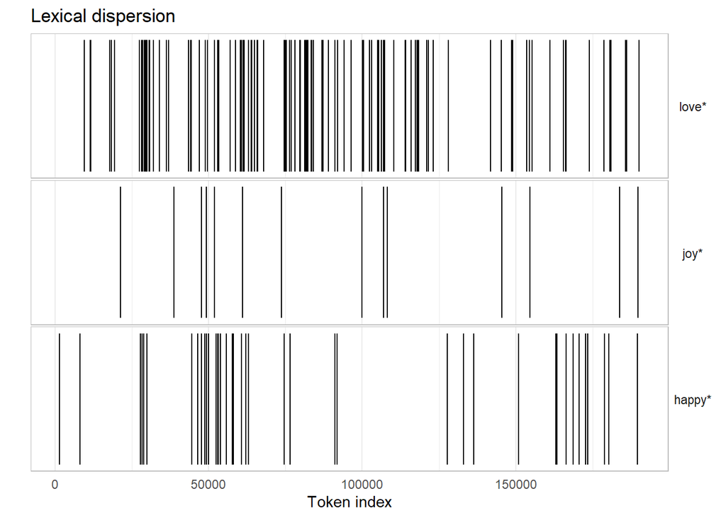

```r
textplot_xray(kwic(novel_lower_v, pattern = "love*"),
    kwic(novel_lower_v, pattern = "joy*"), kwic(novel_lower_v,
        pattern = "happy*")) + ggtitle("Lexical dispersion")
```

We can observe some curious things. For example, about the 30000 token index, there is a lot of words about love and, coincidentally, some about happy. Apart from that, these words seems to be quite uniformly distributed throughout the novel.

# 5 Chapter breaks.

We can also search for the chapter break locations, and thus, divide the book in a collection of documents each one corresponding to a chapter.

```r
chapters_corp <- corpus(novel_lower_v) %>%
    corpus_segment(pattern = "chapter\\s.+\n+.*\\n",
        valuetype = "regex")
summary(chapters_corp, 10)
```

```
Corpus consisting of 27 documents, showing 10 documents:

     Text Types Tokens Sentences
  text1.1  1488   6605        15
  text1.2  1336   6415        31
  text1.3  1433   6591        47
  text1.4  1380   6817        43
  text1.5   908   4212        22
  text1.6  1466   6799        47
  text1.7  1516   6583        16
  text1.8  1488   7420        23
  text1.9  1289   7069        29
 text1.10  1274   7155        59
                                                              pattern
                             chapter i\n\njonathan harker's journal\n
               chapter ii\n\njonathan harker's journal--_continued_\n
              chapter iii\n\njonathan harker's journal--_continued_\n
               chapter iv\n\njonathan harker's journal--_continued_\n
 chapter v\n\n_letter from miss mina murray to miss lucy westenra._\n
                                chapter vi\n\nmina murray's journal\n
             chapter vii\n\ncutting from "the dailygraph," 8 august\n
                              chapter viii\n\nmina murray's journal\n
            chapter ix\n\n\n_letter, mina harker to lucy westenra._\n
       chapter x\n\n\n_letter, dr. seward to hon. arthur holmwood._\n
```

Notice that we can extract the titles of the chapters into the `pattern` document variables. To tidy this up, we can remove the trailing **\n** character, using **stri_trim_right()**.

```r
docvars(chapters_corp, "pattern") <- stringi::stri_trim_right(docvars(chapters_corp,
    "pattern"))
summary(chapters_corp, n = 3)
```

```
Corpus consisting of 27 documents, showing 3 documents:

    Text Types Tokens Sentences
 text1.1  1488   6605        15
 text1.2  1336   6415        31
 text1.3  1433   6591        47
                                               pattern
                chapter i\n\njonathan harker's journal
  chapter ii\n\njonathan harker's journal--_continued_
 chapter iii\n\njonathan harker's journal--_continued_
```

# 6 Ocurrence of love-related words by character.

With the corpus split into chapters, we can use the **dfm()** function to create a matrix of counts of each word in each chapter – a document-frequency matrix. Then, as in this novel each chapter is a first person text (fictionally) written by one of the main characters, we can find who wrote the chapters with the most frequency of positive related words. In particular, we will use only the words starting for love.

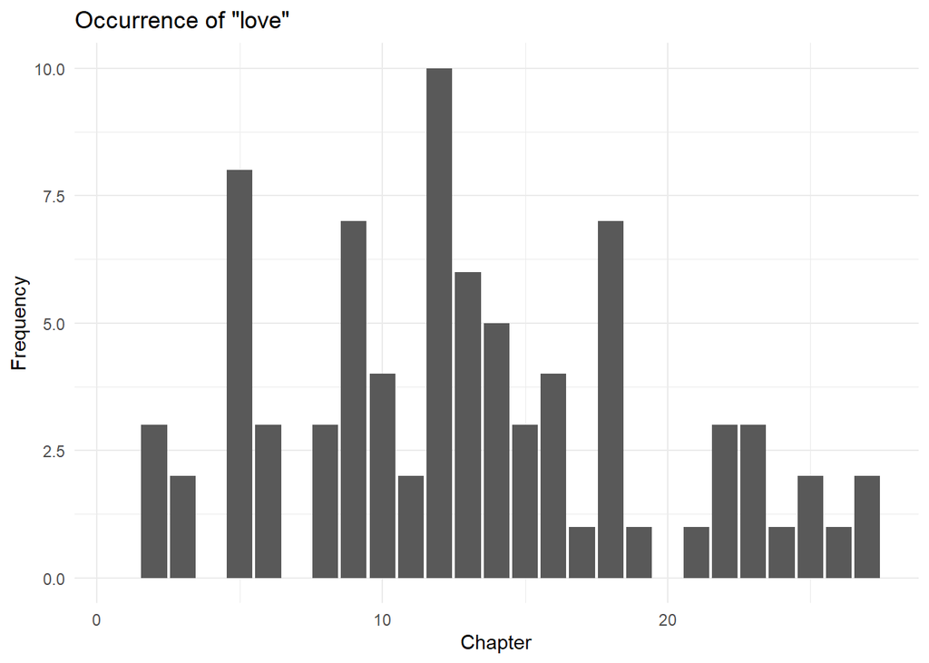

```r
# create a dfm
chap_dfm <- dfm(chapters_corp)

# extract row with count for 'love' in each
# chapter and convert to data frame for plotting
love_happy_df <- chap_dfm %>%
    dfm_keep(pattern = "love*") %>%
    convert(to = "data.frame")

love_happy_df$chapter <- 1:nrow(love_happy_df)

ggplot(data = love_happy_df, aes(x = chapter, y = love)) +
    geom_bar(stat = "identity") + labs(x = "Chapter",
    y = "Frequency", title = "Occurrence of \"love\"")
```

We can also make relative frequency plots, (word count divided by the length of the chapter). To obtain expected word frequency per 100 words, we multiply by 100.

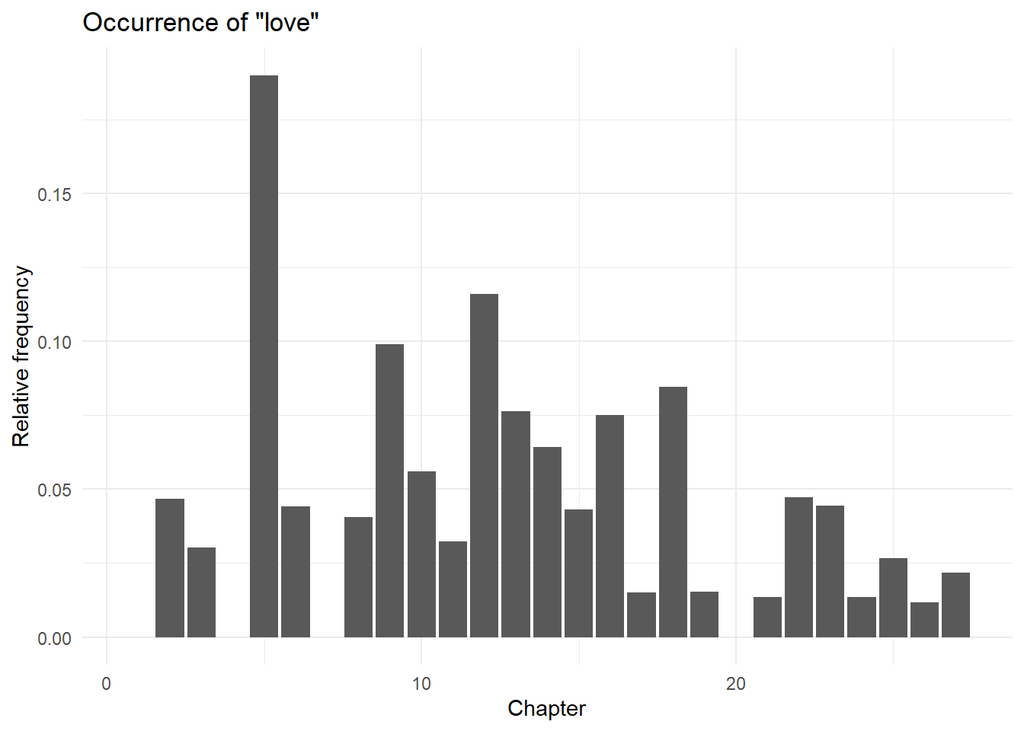

```r
rel_dfm <- dfm_weight(chap_dfm, scheme = "prop") *
    100

rel_chap_freq <- rel_dfm %>%
    dfm_keep(pattern = "love*") %>%
    convert(to = "data.frame")

rel_chap_freq$chapter <- 1:nrow(rel_chap_freq)
ggplot(data = rel_chap_freq, aes(x = chapter, y = love)) +
    geom_bar(stat = "identity") + labs(x = "Chapter",
    y = "Relative frequency", title = "Occurrence of \"love\"")
```

As we can see, chapters 5 and 12 are the ones with the most frequency. If we take a deep look at these chapters we find that chapter V is a set of letters from Mina to her beloved friend Lucy and Chapter XII is an extract of Dr. Sewards diary in which he tells the story of how he met Lucy and his feelings on her. Then, we can see that the two chapters with the most frequency are written by Mina and Dr. Sewards, but both of them are about their love to Lucy.

# 7 Lexical variety.

To start, we show some important amounts for a novel. These are: number of chapters, number of words by chapter and the mean word frequency by chapter.

```r
# Length of the book in chapters
ndoc(chapters_corp)
```

```
[1] 27
```

```r
# Number of words by chapter
ntoken(chapters_corp) %>%
    head()
```

```
text1.1 text1.2 text1.3 text1.4 text1.5 text1.6
   6605    6415    6591    6817    4212    6799
```

```r
# Mean word frequency by chapter
(ntoken(chapters_corp)/ntype(chapters_corp)) %>%
    head()
```

```
 text1.1  text1.2  text1.3  text1.4  text1.5  text1.6
4.438844 4.801647 4.599442 4.939855 4.638767 4.637790
```

Now, we show a plot of the mean word frequency (normal and scaled).

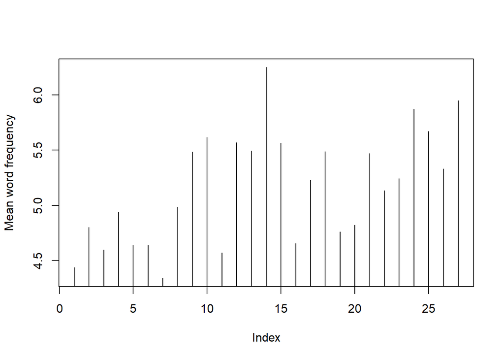

```r
(ntoken(chapters_corp)/ntype(chapters_corp)) %>%
    plot(type = "h", ylab = "Mean word frequency")
```

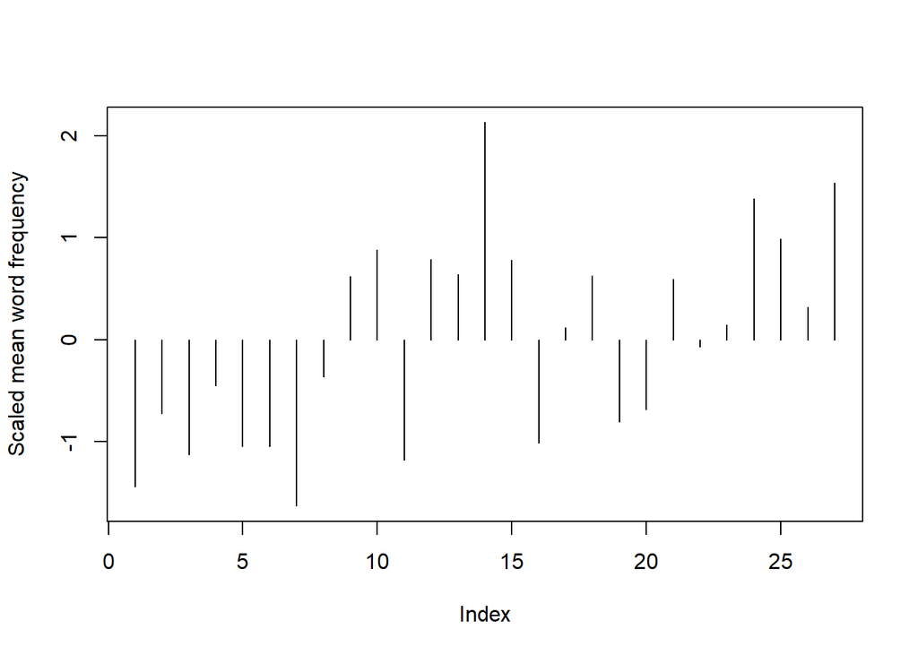

```r
(ntoken(chapters_corp)/ntype(chapters_corp)) %>%
    scale() %>%
    plot(type = "h", ylab = "Scaled mean word frequency")
```

We can also sort the chapters (starting with the ones with the highest mean word frequency).

```r
mean_word_use_m <- (ntoken(chapters_corp)/ntype(chapters_corp))
sort(mean_word_use_m, decreasing = TRUE) %>%
    head()
```

```
text1.14 text1.27 text1.24 text1.25 text1.10 text1.12
6.250804 5.950999 5.871224 5.671212 5.616170 5.568197
```

Finally in this section we compute the TTR (Type-Token Ratio). TTR is the total number of unique words (types) divided by the total number of words (tokens) in a given chapter.

```r
ttr <- dfm(chapters_corp) %>%
    textstat_lexdiv(measure = "TTR")
ttr <- ttr[order(ttr$TTR, decreasing = TRUE), ]
head(ttr, 3)
```

```
   document       TTR
7   text1.7 0.2667383
11 text1.11 0.2601515
1   text1.1 0.2565537
```

Then, the chapters with the greatest TTR are chapter VII, XI and I.

# 8 Calculate the Hapax Richness.

Hapax richness is defined as the number of words that occur only once divided by the total number of words. We compute it by chapter and the proportion.

```r
# hapaxes per chapter
rowSums(chap_dfm == 1) %>%
    head()
```

```
text1.1 text1.2 text1.3 text1.4 text1.5 text1.6
    923     786     897     832     524     919
```

```r
# as a proportion
hapax_proportion <- rowSums(chap_dfm == 1)/ntoken(chap_dfm)
head(hapax_proportion)
```

```
  text1.1   text1.2   text1.3   text1.4   text1.5   text1.6
0.1397426 0.1225253 0.1360947 0.1220478 0.1244065 0.1351669
```

Finally we show a bar plot with the hapax richness for every chapter.

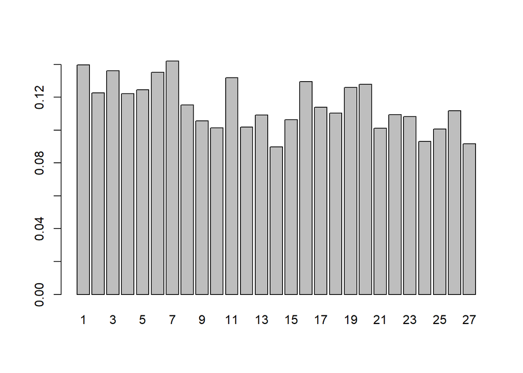

```r
barplot(hapax_proportion, beside = TRUE, col = "grey",
    names.arg = seq_len(ndoc(chap_dfm)))
```